# Estudio de las Notas segun la Carrera

Josue Serulle

2025-05-22

Carga el conjunto de datos de la carpeta data llamado grades.txt en R y responde a las siguientes preguntas:

```r
grades = read.table("../data/grades.txt", header = TRUE)

str(grades)
```

```
## 'data.frame':    200 obs. of  2 variables:
##  $ estudio: chr  "Industrial" "Telematica" "Telematica" "Mates" ...
##  $ nota   : num  4.81 3.83 3.52 0 5.88 ...
```

```r
head(grades)
```

```
##       estudio     nota
## 1  Industrial 4.811598
## 2  Telematica 3.825744
## 3  Telematica 3.518318
## 4       Mates 0.000000
## 5  Telematica 5.879675
## 6 Informatica 3.554049
```

## Pregunta 1

Calcula la media, la mediana y la moda redondeada a dos cifras decimales de las notas numéricas de los exámenes tanto de forma conjunta como por estudio universitario. ¿En qué grupo observamos la nota más alta? ¿Qué grupo está por encima de la media de estudiantes?

```r
mod = function(col){
  round(as.numeric(names(which(table(col) == max(table(col)))))[[1]], 2)
}

round(mean(grades$nota, na.rm = T), 2)
```

```
## [1] 3.87
```

```r
round(median(grades$nota, na.rm = T), 2)
```

```
## [1] 3.5
```

```r
mod(grades$nota)
```

```
## [1] 0
```

```r
aggregate(nota ~ estudio, data = grades, FUN = function(col){round(mean(col, na.rm = T), 2)})
```

```
##       estudio nota
## 1  Industrial 3.58
## 2 Informatica 3.95
## 3       Mates 4.22
## 4  Telematica 3.70
```

```r
aggregate(nota ~ estudio, data = grades, FUN = function(col){round(median(col, na.rm = T), 2)})
```

```
##       estudio nota
## 1  Industrial 3.44
## 2 Informatica 3.48
## 3       Mates 4.10
## 4  Telematica 3.41
```

```r
aggregate(nota ~ estudio, data = grades, FUN = mod)
```

```
##       estudio nota
## 1  Industrial 0.00
## 2 Informatica 1.85
## 3       Mates 0.00
## 4  Telematica 0.00
```

```r
aggregate(nota ~ estudio, data = grades, FUN = function(col){
  round(max(col, na.rm = T), 2)
})
```

```
##       estudio  nota
## 1  Industrial 10.02
## 2 Informatica  8.52
## 3       Mates  8.54
## 4  Telematica  9.29
```

La nota más alta se encuentra en el estudio de Ingeniería Industrial.

## Pregunta 2

¿En qué grupo observamos más variación de notas? Justifica tu respuesta.

```r
aggregate(nota ~ estudio, data = grades, FUN = function(col){round(var(col, na.rm = T), 2)})
```

```
##       estudio nota
## 1  Industrial 4.04
## 2 Informatica 2.37
## 3       Mates 4.82
## 4  Telematica 3.65
```

Hay más variación en el grupo de Mates pues es el que tiene una mayor varianza.

## Pregunta 3

¿Hay mucha diferencia entre el grupo que has respondido en el ejercicio 1 y en el ejercicio 2? Intenta dar una explicación objetiva del suceso.

Hay diferencias claras entre los dos grupos. Por ejemplo, en Industrial alguien sacó un 10, mientras que en Mates la nota más alta fue un 8.54. Aun así, los de Mates tuvieron una media más alta (4.22) que los de Industrial (3.58), lo que sugiere que, en general, les fue mejor a los de Mates. Además, las notas en Mates fueron un poco más variadas (varianza de 4.82 frente a 4.04 en Industrial).

## Pregunta 4

Dibuja en un único gráfico los cuatro diagramas de caja, uno para cada grupo. Añade también la nota media, pon nombre, título y color al gráfico para documentarlo correctamente.

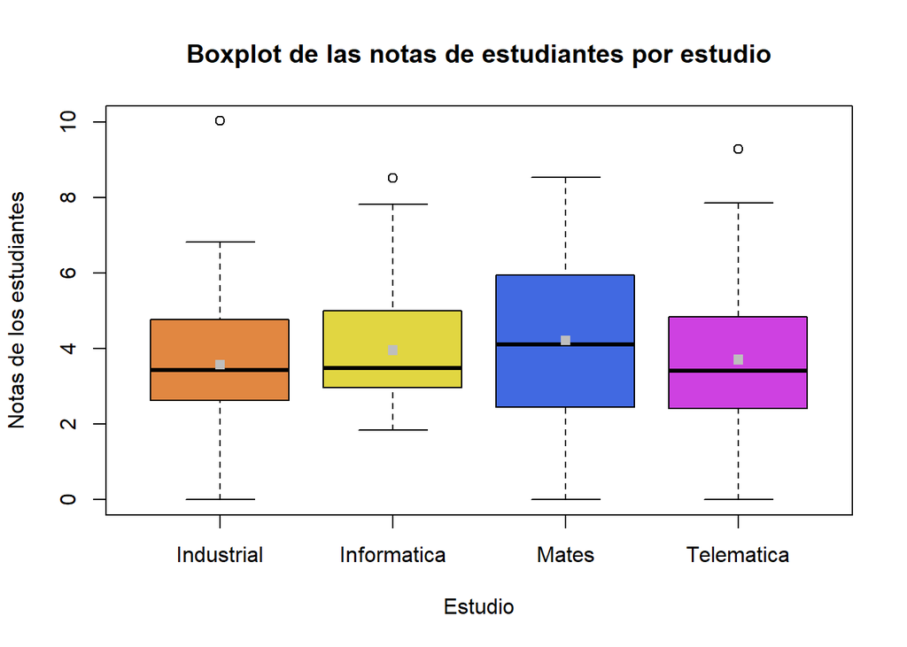

```r
boxplot(nota ~ estudio, data = grades,
        ylab = "Notas de los estudiantes",
        xlab = "Estudio",
        main = "Boxplot de las notas de estudiantes por estudio",
        col = c("#e18741","#e1d641","#4169e1", "#ce41e1"))
means = aggregate(nota ~ estudio, data = grades, FUN = mean)
points(means, col = "gray", pch = 15)
```